# Analysis of Police Shootings in the United States (Washington Post, 2015 - Present)

In 2015, the Washington Post published an investigation into police reporting in the US – or rather, the lack of police reporting. As they note in their [Police Shootings Database report](https://www.washingtonpost.com/graphics/investigations/police-shootings-database/), no branch of US government is responsible for ensuring the collection or maintainance of proper reporting of lethal police shootings. While some departments have policies to record police shootings, many do not, and even the FBI’s database of fatal shootings by police is horribly limited in its scope. Since then, the Post has maintained its own database of more than 5000 lethal shootings by police, collecting information on each individual shot and the details surrounding their death.

However, this is all just data. While the Post has conducted its own analysis of the data, it’s worth wondering about the validity of their investigation. We wanted to investigate some of the questions posed by the Washington Post, as well as pose some of our own, and therefore we have turned to their database in order to answer the questions we were wondering the most about.

## Flight Status

Each entry in the Post database lists a “flight status” – that is, if a shot individual was attempting to flee, and if so, how. We decided to examine this factor, in an attempt to answer some questions about the police’s justification in their use of deadly force. How many people were shot while attempting to get away from the police, and what did these attempts look like?

In the table seen below, we can see a summary of the data for each “flight method.” We included both the raw counts method, as well as percentages indicating the proportions of the total each escape attempt comprised. We then decided to plot the data to compare visually how each of these groups compared.

```
##    Flee Method Total Percent of Total
## 1  Not fleeing  3505        62.678827
## 2          Car   923        16.505722
## 3         Foot   717        12.821888
## 4 not recorded   271         4.846209
## 5        Other   176         3.147353
```

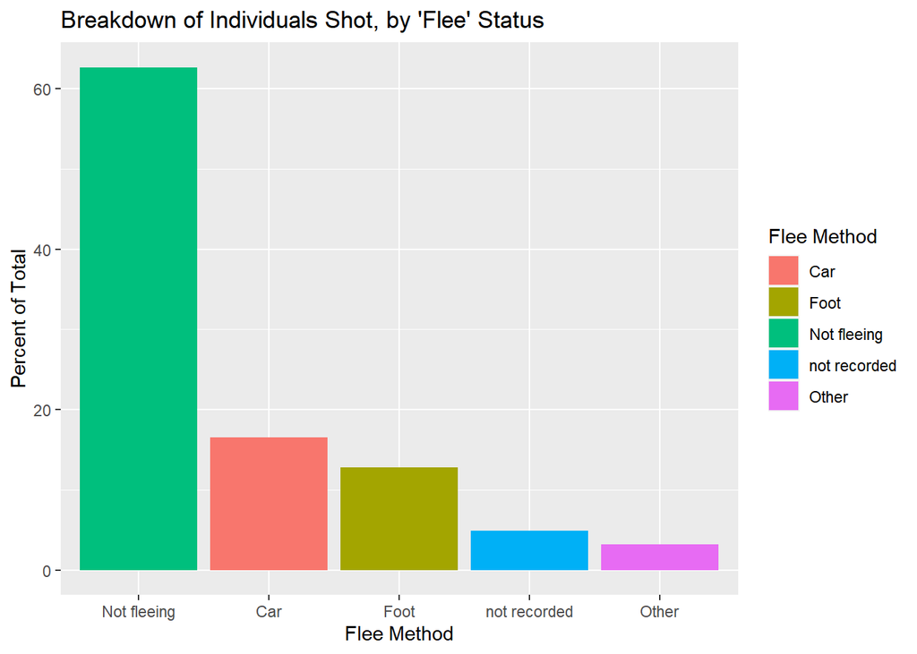

The majority of individuals shot are categorized as “not fleeing” (62%), while the remaining 38% flee typically by car and by foot. Cars are used slightly more for an attempted escape compared to fleeing on foot. We could not determine the method of flight for the roughly 3% of cases marked “Other,” and also note that nearly 5% of cases did not record flight status in the police report. This might affect some of the numbers and percentages, although if we assume that flight statuses are typically recorded when suspects try to get away and are omitted when they do not, we expect that this would most likely cause the most significant boost to the “Not Fleeing” category.

#### Unarmed & Fleeing – Miscarriages of Justice

It is important to recognize that an individual’s attempt to escape the police is **not** synonymous with being harmless to the officer or others. For example, as the Washington Post’s dataset “readme” file states, a suspect might fire a gun at the officer at the same time as they are trying to escape. Therefore, it doesn’t make sense to conclude from the data that the 38% of “fleeing” individuals were wrongfully killed – after all, they might have simultaneously attempted to escape **and** represented a significant and lethal risk to the officer.

```
##   Flee Status Number Shot Percent of Total Fleeing   Armed
## 1         Car          68                1.2160229 Unarmed
## 2        Foot          76                1.3590844 Unarmed
## 3       Other          11                0.1967096 Unarmed
```

#### Unarmed Individuals and Non-Weapons

Broadening our scope to examine individuals of all flight statuses, we next examined those who were not armed with what might be a significant weapon. Granted, one might consider even an “unarmed” individual to have a significant weapon, in the sense of having a body and being willing to use it to cause harm. However, in this case, we interpreted “lacking a significant weapon” to mean anyone who is listed as “unarmed”, “claimed to be armed” (cop could not see a weapon), anyone with a “toy weapon”, and any cases where the “armed” status was unrecorded. (As before with the flight status, we make the assumption that an officer would record a weapon if it existed, and that it is more likely that the lack of recording correlates to lacking a weapon.) These are interesting cases to examine, however we caution against drawing any strong conclusions from this data given the ambiguity surrounding the details.

```
## # A tibble: 4 x 4
## # Groups:   Armed Status [4]
##   `Armed Status`      Total `Proportion of Unarmed` `Percentage of Total`
##   <chr>               <int>                   <dbl>                 <dbl>
## 1 unarmed               356                  46.7                  6.37
## 2 not recorded          213                  27.9                  3.81
## 3 toy weapon            193                  25.3                  3.45
## 4 claimed to be armed     1                   0.131                0.0179
```

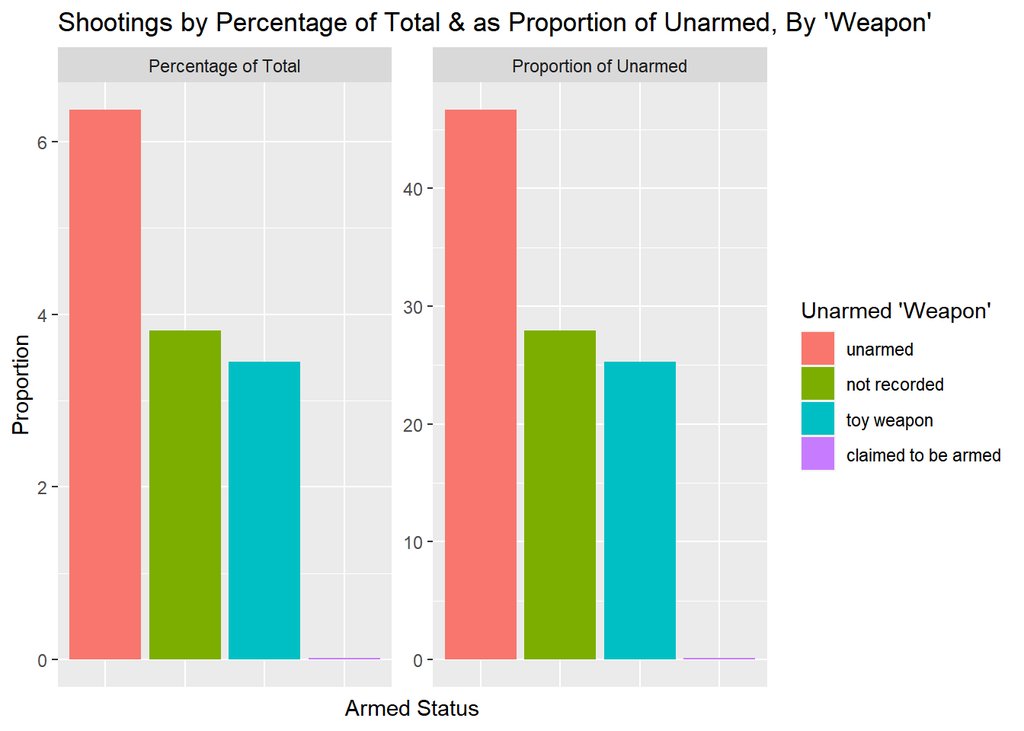

## Racial Analysis

The Washington Post data contains information about the race of each individual, which is extremely useful when subjected to a thorough data analysis. For example, one of the most pressing questions of the current political moment (and perhaps much of the political past, too) is, “Are there racial disparities in outcomes with police, and if so, how do racial groups differ in this regard?” If there are differences (and we suspect there are – the reason for our seeming skepticism is purely a scientific precaution against any accusation of bias), then we expect to see this reflected in the data.

#### Sums by Raw Numbers

```
## # A tibble: 7 x 3
## # Groups:   Race [7]
##   Race            Total `Proportion of Total`
##   <fct>           <int>                 <dbl>
## 1 White            2530                45.2
## 2 Black            1318                23.6
## 3 Hispanic          920                16.5
## 4 not recorded      606                10.8
## 5 Asian              93                 1.66
## 6 Native American    78                 1.39
## 7 Other              47                 0.840
```

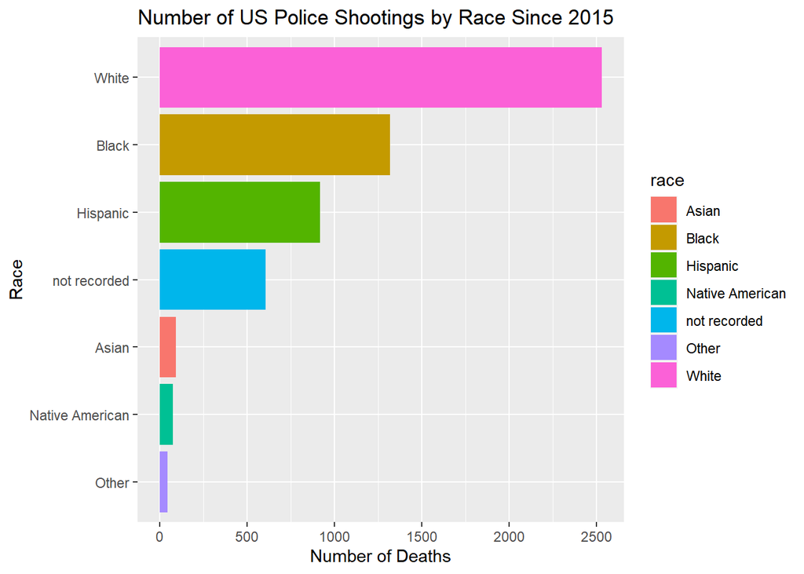

Indeed, this is what we see when looking at the sum totals. Roughly 2500 white individuals have been fatally shot by police since 2015, leading any other group in raw counts; this is roughly double the black population’s police shootings, at 1300 people. In fact, if we omit the “not recorded” category from the data, white individuals account for more police shootings than all other races combined. Asians, Native Americans, and all “Other” races make up a very small number of deaths, by the numbers.

One important note about the plots: The year 2020 looks like a positive year for police shootings. It is not. Because this data is still being recorded, the dataset is incomplete, and the numbers are likely to continue to increase (a lot) over the remainder of the year. Police shootings numbers have remained roughly constant across all years of the dataset. The number of white individuals shot each year seems to be falling somewhat, but we will need to wait until the end of 2020 to see if this is a trend or simply a statistical anomaly.

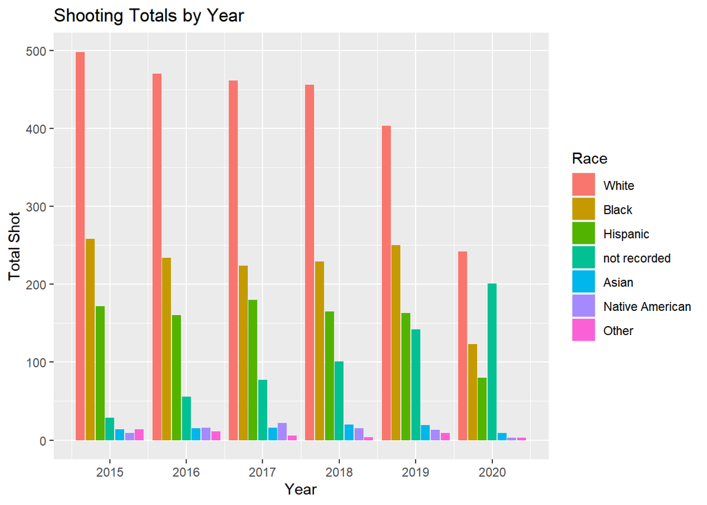

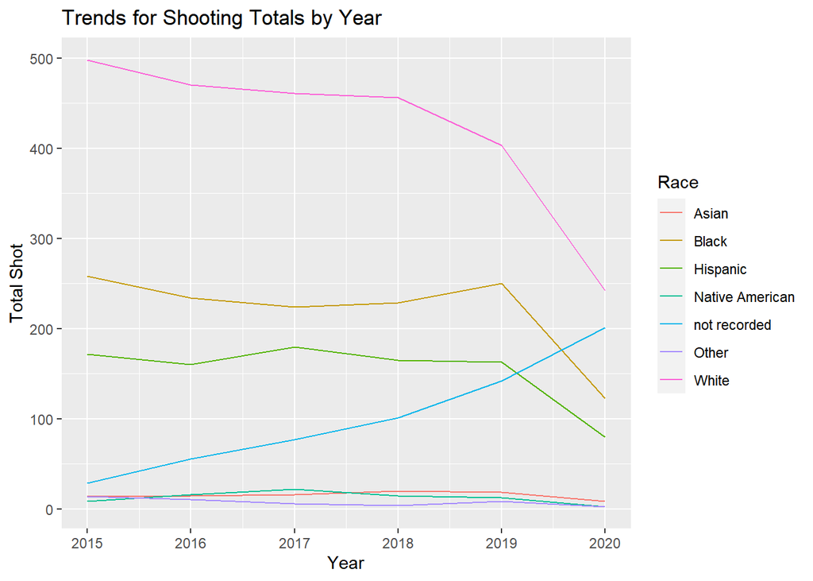

#### Normalization of a Statistical Nature

The way this normalization works can be thought of like so: Imagine a room of 50 white people, 20 black people, 20 Hispanic, and 10 Asian people. (No, this is not representative of the USA.) If you were to walk into this room and randomly select 10 people, you would expect that 5 of them should be white, 2 should be black, 2 Hispanic, and 1 should be Asian. Truly “random” shooting by police would result in a similar outcome. Given that we expect each race to be represented to varying degrees, one trick we can do is to divide by how many we expect to see. If we get a “1” for each category, then our selection process is likely random; if we get higher than 1, it biases toward choosing individuals from these groups, and if we get less than 1, it biases away from these groups.

This example illustrates how we applied normalization to our dataset. Indeed, when we do this, we arrive at the shocking/obvious (depending on the person) conclusion that Native Americans and Blacks are biased toward *higher* shooting counts than predicted by their populations alone, while Hispanics, Whites, Asians, and “Other”-classified races are biased toward *lower* shooting counts than predicted. This can be seen in the data table below, as well as in the plot. (The data table contains additional information that the plot does not show; in particular, there is the “not recorded” category, which we were unable to normalize for. We aren’t sure where these numbers would contribute to, although one theory is that it might bolster the counts for non-white individuals shot.)

```
##              Race Total Shot Percent Of US Ratio Shot vs Population
## 1 Native American         78     0.6440338                2.1658023
## 2           Black       1318    12.1074807                1.9466795
## 3        Hispanic        920    18.3980170                0.8942309
## 4           White       2530    60.5574299                0.7471124
## 5           Asian         93     5.2152087                0.3188923
## 6           Other         47     3.0778300                0.2730776
## 7    not recorded        606            NA                       NA
```

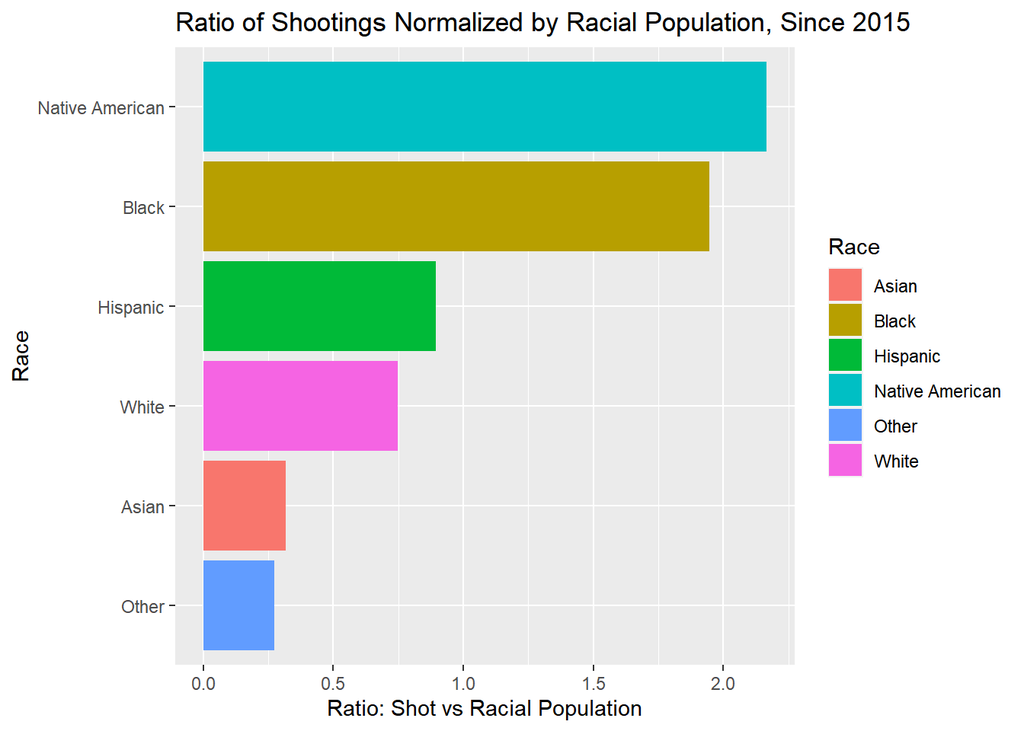

We see a similar story when looking at the normalized numbers by year: Native Americans are anywhere from **1.5 to 3.5 times** as likely to be shot fatally by police, as compared to their US population percentage. Blacks follow this at approximately **two times** as likely to be fatally shot.[^1] By comparison, Hispanics and whites are *less* likely than their population indicates to be shot; Hispanics are roughly 0.8 times as likely to be shot compared to their population estimate, and whites are in the range of 0.7 times. Asians occupy the lowest (along with the mysterious “Other” classification) ratio, at around 0.3 times their population.

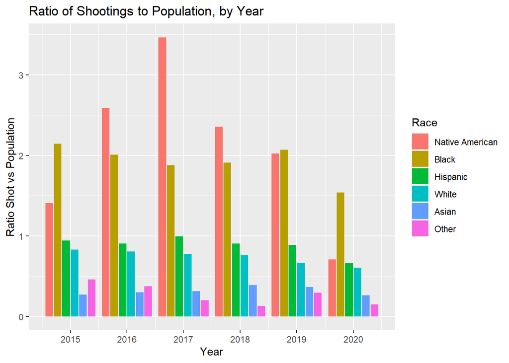

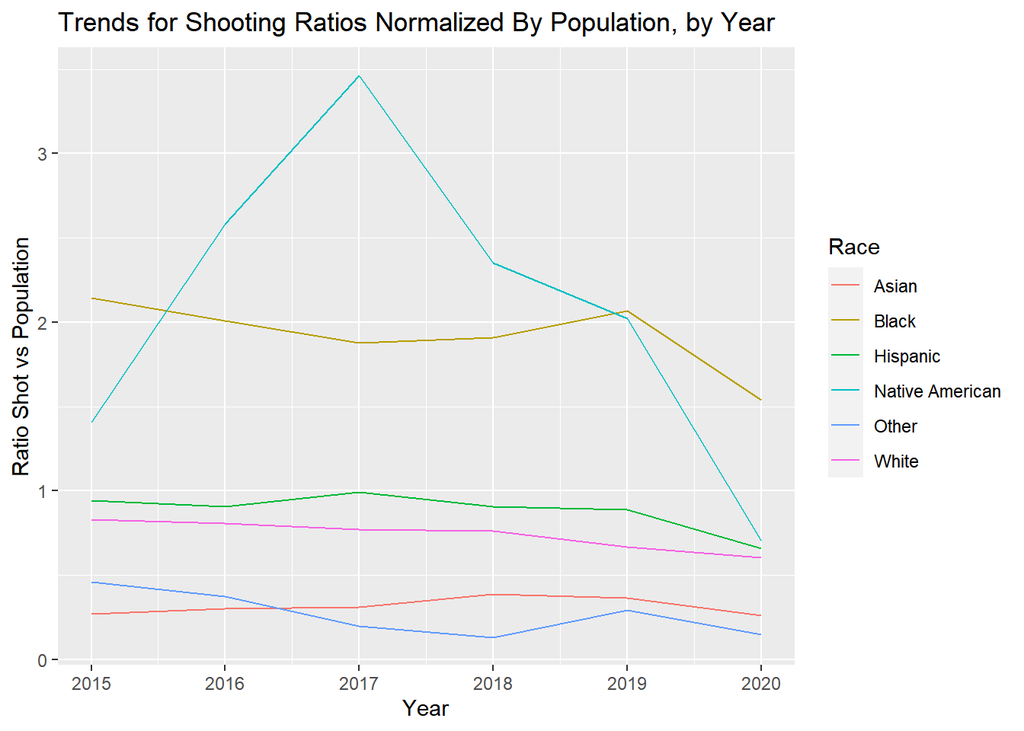

## Conclusions

As a final conclusion, one thing is certainly clear: Police need more training. There are roughly 1000 fatal shootings by police each year, and the number appears to hold constant across time. Policing is hard work; it’s difficult and requires a great deal of bravery and self-sacrifice. But proper policing also requires skill, and if we want to see improvements in the results obtained in this analysis, we need to ensure that police receive proper training to do their jobs effectively. It’s clear that poor policing hurts everyone in the United States, and this is something that have an obligation to fix.

[^1]: As has been [pointed out](https://www.channel4.com/news/factcheck/factcheck-black-americans-commit-crime), black Americans commit more than 50 percent of violent crime; blacks committed 52 percent of homicides between 1980 and 2008. While the more recent numbers are reduced from this figure, in 2013 the FBI recorded that blacks carried out 38 percent of murders, compared to 31 percent for whites. This should not be taken as rationalization and justification for the above-population-level (aka “1.0”) normalization ratio, but it might explain part of it. After all, if blacks make up 13% of the population but commit 50% of violent crime, where *should* the proportion of black individuals shot by police fall? We’re certainly not inclined to believe it ought to be as high as 50%, but it also doesn’t seem reasonable to expect it to be 13 percent, either.